# Lecture 15: Causal inference

Economics 326 — Introduction to Econometrics II

Author

Vadim Marmer, UBC

Published

April 5, 2026

## Motivation: causal questions

- Many important questions in economics are **causal**:
  - Does job training increase earnings?
  - Does a new drug improve health outcomes?
- The **fundamental challenge**: we can never observe the same individual both with and without treatment at the same time.
- This is modeled using the **potential outcomes framework**: each individual has two potential outcomes, one under treatment and one under control, but we only observe one of them.

## Potential outcomes

- **Treatment status**: $D_i = 1$ if individual $i$ receives treatment, $D_i = 0$ otherwise.
- For each individual $i$, define two **potential outcomes**:
  - $Y_i(1)$: outcome if individual $i$ receives treatment ($D_i = 1$),
  - $Y_i(0)$: outcome if individual $i$ does not receive treatment ($D_i = 0$).
- The **individual treatment effect** for person $i$ is:

  $$Y_i(1) - Y_i(0).$$
- Example: if $Y_i$ is earnings and $D_i$ indicates job training, then $Y_i(1) - Y_i(0)$ is the causal effect of training on earnings for person $i$.

## The fundamental problem

- The **observed outcome** is:

  $$Y_i = D_i \, Y_i(1) + (1 - D_i) \, Y_i(0).$$
- If $D_i = 1$, we observe $Y_i(1)$ but not $Y_i(0)$.
- If $D_i = 0$, we observe $Y_i(0)$ but not $Y_i(1)$.
- We can never observe both potential outcomes for the same individual. This is the **fundamental problem of causal inference**.

## Causal parameters of interest

- **Average Treatment Effect (ATE):**

  $$\text{ATE} = \mathrm{E}\left[Y_i(1) - Y_i(0)\right].$$
- **Average Treatment Effect on the Treated (ATT):**

  $$\text{ATT} = \mathrm{E}\left[Y_i(1) - Y_i(0) \mid D_i = 1\right].$$
- **Conditional Average Treatment Effect (CATE):**

  $$\text{CATE}(\mathbf{x}) = \mathrm{E}\left[Y_i(1) - Y_i(0) \mid \mathbf{X}_i = \mathbf{x}\right].$$
- ATE averages over the entire population; ATT averages only over those who actually receive treatment; CATE conditions on observable characteristics $\mathbf{X}_i$.

## Selection bias

- Since we cannot observe the counterfactual for each individual, a natural idea is to use the outcomes of **other people** as stand-ins: compare average outcomes of the treated group to average outcomes of the untreated group.
- Can we estimate ATE by simply comparing group averages, $\mathrm{E}\left[Y_i \mid D_i = 1\right] - \mathrm{E}\left[Y_i \mid D_i = 0\right]$?
- Comparing group averages seems natural, but it conflates the treatment effect with pre-existing differences between groups:

  $$\begin{align*}
  &\mathrm{E}\left[Y_i \mid D_i = 1\right] - \mathrm{E}\left[Y_i \mid D_i = 0\right] \\
  &= \mathrm{E}\left[Y_i(1) \mid D_i = 1\right] - \mathrm{E}\left[Y_i(0) \mid D_i = 0\right].
  \end{align*}$$
- Add and subtract $\mathrm{E}\left[Y_i(0) \mid D_i = 1\right]$:

  $$\begin{align*}
  &= \underbrace{\mathrm{E}\left[Y_i(1) - Y_i(0) \mid D_i = 1\right]}_{\text{ATT}} \\
  &\quad + \underbrace{\mathrm{E}\left[Y_i(0) \mid D_i = 1\right] - \mathrm{E}\left[Y_i(0) \mid D_i = 0\right]}_{\text{Selection bias}}.
  \end{align*}$$
- **Selection bias** arises when the treatment and control groups differ in their baseline outcomes $Y_i(0)$.
- E.g., people who choose to enroll in job training may differ systematically from those who do not.

## Random assignment

- **Randomization** solves the selection problem: by randomly assigning treatment, we ensure the treated and control groups are comparable in expectation.
- Under **random assignment**, treatment $D_i$ is independent of potential outcomes:

  $$\mathrm{E}\left[Y_i(0) \mid D_i = 1\right] = \mathrm{E}\left[Y_i(0) \mid D_i = 0\right] = \mathrm{E}\left[Y_i(0)\right].$$
- The selection bias vanishes, and the simple difference in means equals the ATE:

  $$\begin{align*}
  &\mathrm{E}\left[Y_i \mid D_i = 1\right] - \mathrm{E}\left[Y_i \mid D_i = 0\right] \\
  &= \mathrm{E}\left[Y_i(1) - Y_i(0)\right] = \text{ATE} = \text{ATT}.
  \end{align*}$$
- Randomized experiments (like the National Supported Work program) achieve this by randomly assigning individuals to treatment and control groups.

## Regression with a treatment dummy

- With random assignment, the ATE can be estimated by regressing $Y_i$ on a treatment dummy:

  $$Y_i = \alpha + \tau D_i + U_i,$$

  where $\mathrm{E}\left[U_i \mid D_i\right] = 0$ under randomization.
- The OLS estimate of $\tau$ equals the difference in sample means:

  $$\hat{\tau} = \bar{Y}_1 - \bar{Y}_0,$$

  where $\bar{Y}_1$ and $\bar{Y}_0$ are the sample averages for the treated and control groups.

## Example: Lalonde data

- The **National Supported Work (NSW)** demonstration recruited disadvantaged workers (long-term unemployed, high-school dropouts, former drug users, ex-offenders).
- Among eligible applicants, some were **randomly assigned** to receive job training (treated group), and the rest formed the **experimental control group**. Both groups come from the same disadvantaged population.
- We use the `jtrain2` dataset from the `wooldridge` package, based on the Lalonde (1986) study:

  ```r
  library(wooldridge)
  data(jtrain2)
  set.seed(326)
  jtrain2[sample(nrow(jtrain2), 10), c("train", "re78", "educ", "age", "black", "married")]
  ```

  ```
      train     re78 educ age black married
  357     0  3.34322    9  21     1       0
  320     0 10.79860    8  18     0       0
  108     1  1.95327    9  17     1       0
  364     0  0.00000   11  39     1       0
  256     0  0.00000   12  24     1       0
  415     0  0.00000    8  23     1       0
  222     0  2.01550   10  20     1       0
  100     1 26.81760    9  31     0       0
  145     1  2.48455   12  31     0       0
  244     0 12.89840    9  22     1       0
  ```

- `train`: 1 if randomly assigned to job training, 0 if assigned to control.
- `re78`: real earnings in 1978 (thousands of dollars).

## Estimating the ATE

- Since treatment was randomly assigned, the coefficient on `train` estimates the ATE:

  ```r
  summary(lm(re78 ~ train, data = jtrain2))$coefficients
  ```

  ```
              Estimate Std. Error   t value     Pr(>|t|)
  (Intercept) 4.554802  0.4080460 11.162474 1.154113e-25
  train       1.794343  0.6328536  2.835321 4.787524e-03
  ```

- The estimated ATE is approximately $1,800 (`re78` is in thousands): on average, participation in the job training program increased 1978 earnings by about $1,800.

## Observational studies

- In many settings, randomization is not feasible or ethical. Treatment is determined by individual choices or institutional rules.
- Self-selection generates **selection bias**: workers who voluntarily enroll in job training may be more motivated; workers at firms offering 401(k) plans tend to have higher incomes.
- **Key idea**: if we can identify covariates $X_i$ that explain why some individuals are treated and others are not, then **after controlling for $X_i$**, treatment may be as good as random.
- This is the **selection on observables** assumption: all confounding factors are captured by observable covariates.

## Potential outcomes with a covariate

- The selection on observables assumption can be formalized as follows: after conditioning on $X_i$, treatment assignment $D_i$ is as good as random.
- $D_i$ and $X_i$ can be correlated.
- Suppose the potential outcomes depend linearly on a covariate $X_i$:

  $$\begin{align*}
  Y_i(0) &= \alpha_0 + \beta_0 X_i + U_i(0), \\
  Y_i(1) &= \alpha_1 + \beta_1 X_i + U_i(1),
  \end{align*}$$
- **Conditional mean independence assumption:**

  $$\mathrm{E}\left[U_i(0) \mid X_i, D_i\right] = 0 \quad \text{and} \quad \mathrm{E}\left[U_i(1) \mid X_i, D_i\right] = 0.$$
- That is, after controlling for $X_i$, the residual terms $U_i(0)$ and $U_i(1)$ are uncorrelated with treatment $D_i$.
- The effect of $X_i$ on the potential outcomes can differ between the treated and control groups: $\beta_1$ may not equal $\beta_0$.

## The ATE with a covariate

- Taking expectations of the potential outcomes:

  $$\begin{align*}
  \mathrm{E}\left[Y_i(1)\right] &= \alpha_1 + \beta_1 \mathrm{E}\left[X_i\right], \\
  \mathrm{E}\left[Y_i(0)\right] &= \alpha_0 + \beta_0 \mathrm{E}\left[X_i\right].
  \end{align*}$$
- The ATE is:

  $$\begin{align*}
  \text{ATE} &= \mathrm{E}\left[Y_i(1) - Y_i(0)\right] \\
  &= (\alpha_1 - \alpha_0) + (\beta_1 - \beta_0)\mathrm{E}\left[X_i\right].
  \end{align*}$$
- The ATE depends on the difference in intercepts **and** the difference in slopes, weighted by the population mean of $X_i$.

## Two separate regressions

- One approach: estimate separate regressions for each group.
- **Control group** ($D_i = 0$): $Y_i = \alpha_0 + \beta_0 X_i + U_i(0).$
- **Treatment group** ($D_i = 1$): $Y_i = \alpha_1 + \beta_1 X_i + U_i(1).$
- The estimated ATE is:

  $$\begin{align*}
  \widehat{\text{ATE}} &= (\hat{\alpha}_1 - \hat{\alpha}_0) \\
  &\quad + (\hat{\beta}_1 - \hat{\beta}_0)\bar{X},
  \end{align*}$$

  where $\bar{X}$ is the overall sample mean of $X_i$.

## Combined regression with interactions

- The observed outcome $Y_i = D_i Y_i(1) + (1 - D_i) Y_i(0)$ can be written as a single regression. Expanding:

  $$\begin{align*}
  Y_i &= D_i \underbrace{({\color{blue}\alpha_1} + {\color{blue}\beta_1} X_i + {\color{blue}U_i(1)})}_{Y_i(1)} + (1 - D_i)\underbrace{({\color{red}\alpha_0} + {\color{red}\beta_0} X_i + {\color{red}U_i(0)})}_{Y_i(0)} \\
  &= {\color{red}\alpha_0}(1 - D_i) + {\color{blue}\alpha_1} D_i \\
  &\quad + {\color{red}\beta_0} X_i(1 - D_i) + {\color{blue}\beta_1} X_i D_i + (1 - D_i){\color{red}U_i(0)} + D_i {\color{blue}U_i(1)} \\
  &= {\color{red}\alpha_0} + ({\color{blue}\alpha_1} - {\color{red}\alpha_0})D_i \\
  &\quad + {\color{red}\beta_0} X_i + ({\color{blue}\beta_1} - {\color{red}\beta_0})X_i D_i + U_i,
  \end{align*}$$

  where $U_i = (1 - D_i){\color{red}U_i(0)} + D_i {\color{blue}U_i(1)}$.
- This is a regression of $Y_i$ on $D_i$, $X_i$, and the interaction $X_i D_i$:

  $$Y_i = \alpha_0 + \gamma D_i + \beta_0 X_i + \delta X_i D_i + U_i,$$

  where $\gamma = {\color{blue}\alpha_1} - {\color{red}\alpha_0}$ and $\delta = {\color{blue}\beta_1} - {\color{red}\beta_0}$.
- The coefficient on $D_i$ is $\gamma = \alpha_1 - \alpha_0$, which is **not** the ATE (unless $\beta_1 = \beta_0$).

## The demeaning trick

- Recall that $\text{ATE} = (\alpha_1 - \alpha_0) + (\beta_1 - \beta_0)\mathrm{E}\left[X_i\right]$, but the coefficient on $D_i$ is only $\alpha_1 - \alpha_0$. To fix this, **add and subtract** $(\beta_1 - \beta_0)\mathrm{E}\left[X_i\right]D_i$:

  $$\begin{align*}
  Y_i &= \alpha_0 + (\alpha_1 - \alpha_0)D_i + \beta_0 X_i + (\beta_1 - \beta_0) X_i D_i + U_i \\
  &= \alpha_0 + \big[(\alpha_1 - \alpha_0) + {\color{blue}(\beta_1 - \beta_0)\mathrm{E}\left[X_i\right]}\big]D_i \\
  &\quad + \beta_0 X_i + (\beta_1 - \beta_0) X_i D_i {\color{red}{}- (\beta_1 - \beta_0)\mathrm{E}\left[X_i\right]D_i} + U_i \\
  &= \alpha_0 + \underbrace{\big[(\alpha_1 - \alpha_0) + {\color{blue}(\beta_1 - \beta_0)\mathrm{E}\left[X_i\right]}\big]}_{\text{ATE}} D_i \\
  &\quad + \beta_0 X_i + (\beta_1 - \beta_0){\color{red}(X_i - \mathrm{E}\left[X_i\right])}D_i + U_i.
  \end{align*}$$
- Defining $\tau = \text{ATE}$ and $\delta = \beta_1 - \beta_0$:

  $$Y_i = \alpha_0 + \tau D_i + \beta_0 X_i + \delta(X_i - \mathrm{E}\left[X_i\right])D_i + U_i.$$
- The coefficient $\tau$ on $D_i$ is exactly the **ATE**.

## Estimating the ATE with covariates

- In practice, replace $\mathrm{E}\left[X_i\right]$ with the sample mean $\bar{X}$ and run the regression:

  $$\begin{align*}
  Y_i &= \hat{\alpha}_0 + \hat{\tau} D_i + \hat{\beta}_0 X_i \\
  &\quad + \hat{\delta}(X_i - \bar{X})D_i + \text{residual}.
  \end{align*}$$
- The coefficient $\hat{\tau}$ on $D_i$ directly estimates the ATE.
- This works because demeaning the interaction “absorbs” the $(\beta_1 - \beta_0)\mathrm{E}\left[X_i\right]$ part of the ATE into the coefficient on $D_i$.

## Why not regress $Y_i$ on $D_i$ and $X_i$?

- A simpler regression omits the interaction:

  $$Y_i = a + c D_i + b X_i + V_i.$$
- Recall $\delta = \beta_1 - \beta_0$ measures how the effect of $X_i$ differs between the treatment and control groups.
- This is valid if $\beta_1 = \beta_0$ (the covariate has the same effect in both groups). Then $\delta = 0$, the interaction drops out, and the coefficient on $D_i$ is the ATE.
- If $\beta_1 \neq \beta_0$ (the effect of $X_i$ differs between groups), the omitted interaction creates bias: the interaction $X_iD_i$ affects $Y_i$ and is correlated with $D_i$, so the coefficient on $D_i$ does not equal the ATE.

## Example: separate regressions

- Estimate separate regressions of `re78` on `educ` for the treatment and control groups:

  ```r
  reg0 <- lm(re78 ~ educ, data = jtrain2, subset = (train == 0))
  reg1 <- lm(re78 ~ educ, data = jtrain2, subset = (train == 1))
  cbind(Control = coef(reg0), Treatment = coef(reg1))
  ```

  ```
                 Control  Treatment
  (Intercept) 3.80301658 -0.7821703
  educ        0.07451936  0.6892860
  ```

- Compute the estimated ATE:

  ```r
  xbar <- mean(jtrain2$educ)
  a0 <- coef(reg0)[1]; b0 <- coef(reg0)[2]
  a1 <- coef(reg1)[1]; b1 <- coef(reg1)[2]
  ATE_manual <- (a1 - a0) + (b1 - b0) * xbar
  cat("Sample mean of educ:", round(xbar, 2), "\n")
  ```

  ```
  Sample mean of educ: 10.2
  ```

  ```r
  cat("Estimated ATE:", round(ATE_manual, 2), "\n")
  ```

  ```
  Estimated ATE: 1.68
  ```

## Example: regression lines

- The two regression lines, with a vertical line at $\bar{X}$ and the ATE marked as the gap:

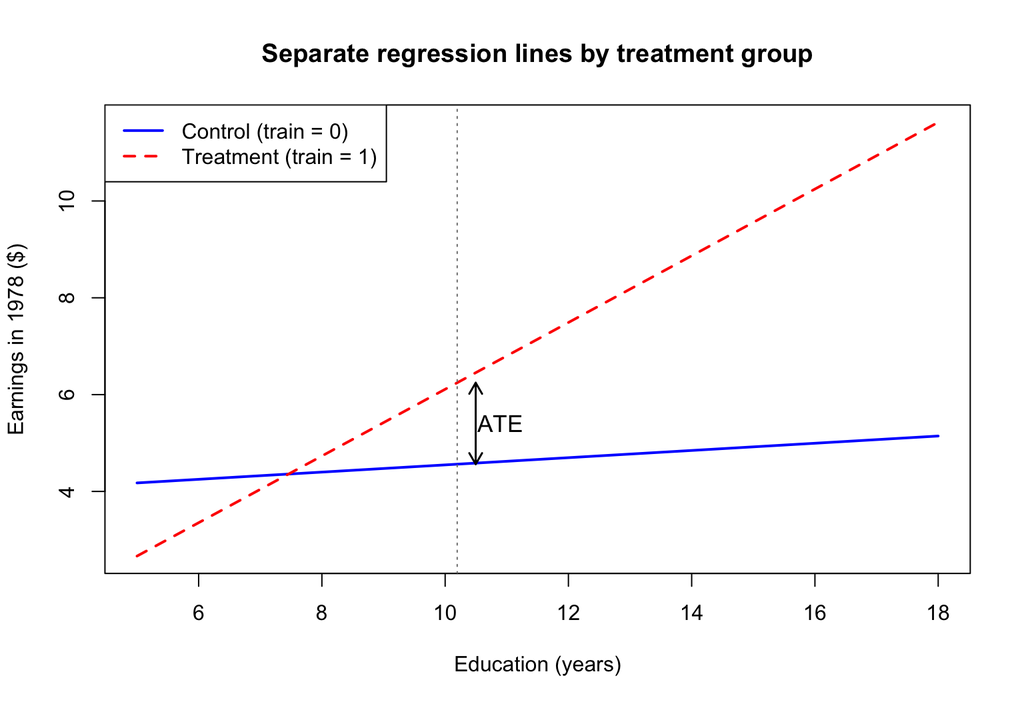

## Example: demeaned regression

- Create the demeaned interaction and run the combined regression:

  ```r
  jtrain2$educ_dm <- jtrain2$educ - mean(jtrain2$educ)
  reg_dm <- lm(re78 ~ train + educ + I(train * educ_dm), data = jtrain2)
  summary(reg_dm)$coefficients
  ```

  ```
                       Estimate Std. Error   t value   Pr(>|t|)
  (Intercept)        3.80301658  2.5689136 1.4803988 0.13948090
  train              1.68266981  0.6299604 2.6710725 0.00784062
  educ               0.07451936  0.2514521 0.2963561 0.76709766
  I(train * educ_dm) 0.61476663  0.3472755 1.7702560 0.07737534
  ```

- The coefficient on `train` directly estimates the ATE, matching the result from the separate regressions approach.

## Example: adding more covariates

  ```r
  reg_X <- lm(re78 ~ train + educ + age + black + married, data = jtrain2)
  round(summary(reg_X)$coefficients, 1)
  ```

  ```
              Estimate Std. Error t value Pr(>|t|)
  (Intercept)      0.9        2.2     0.4      0.7
  train            1.7        0.6     2.7      0.0
  educ             0.4        0.2     2.4      0.0
  age              0.1        0.0     1.2      0.2
  black           -2.3        0.8    -2.7      0.0
  married          0.2        0.8     0.2      0.9
  ```

## Comparison: simple vs. controlled

- Compare the estimated ATE and its standard error across specifications, including one with demeaned interactions:

  ```r
  m1 <- lm(re78 ~ train, data = jtrain2)
  m2 <- lm(re78 ~ train + educ + age + black + married, data = jtrain2)
  covs <- c("educ", "age", "black", "married")
  for (v in covs) jtrain2[[paste0(v, "_dm")]] <- jtrain2[[v]] - mean(jtrain2[[v]])
  m3 <- lm(re78 ~ train + educ + age + black + married +
             I(train * educ_dm) + I(train * age_dm) +
             I(train * black_dm) + I(train * married_dm), data = jtrain2)
  make_row <- function(m) c(Estimate = coef(m)["train"],
                            SE = summary(m)$coef["train", "Std. Error"])
  tab <- rbind(
    "No controls"            = make_row(m1),
    "Controls, equal slopes"  = make_row(m2),
    "Demeaned interactions"   = make_row(m3)
  )
  round(tab, 2)
  ```

  ```
                         Estimate.train   SE
  No controls                      1.79 0.63
  Controls, equal slopes           1.68 0.63
  Demeaned interactions            1.64 0.63
  ```

## Why do controls change little here?

- Under **random assignment**, $D_i$ is independent of all covariates: the treatment and control groups are balanced in expectation.
- Because of balance, including $X_i$ does not change the coefficient on $D_i$: there is no selection bias to remove.
- The NSW program recruited a narrow, disadvantaged population: long-term unemployed, high-school dropouts, former drug users, ex-offenders.
- Within this homogeneous group, covariates like `educ`, `age`, `black`, and `married` vary little and have limited predictive power for earnings.
- Both the point estimate and the standard error are nearly unchanged because the controls add almost no information beyond the treatment dummy.

## Example: 401(k) eligibility and savings

- The `k401ksubs` dataset (from the `wooldridge` package) contains 9,275 households from the 1991 Survey of Income and Program Participation.

  ```r
  data(k401ksubs)
  cat("n =", nrow(k401ksubs), "\n")
  ```

  ```
  n = 9275
  ```

  ```r
  set.seed(326)
  k401ksubs[sample(nrow(k401ksubs), 8), c("e401k", "nettfa", "inc", "age", "marr")]
  ```

  ```
       e401k nettfa    inc age marr
  1893     1 24.200 47.328  55    1
  876      0 -1.000 13.260  45    0
  927      0  0.000 17.571  37    1
  6878     1  7.999 57.843  45    1
  4196     0  8.000 13.800  25    0
  1887     1  6.450 40.980  39    0
  4355     0 29.700 22.410  34    0
  7596     1 18.500 60.300  35    1
  ```

- **Treatment**: `e401k` = 1 if the worker’s employer offers a 401(k) plan, 0 otherwise.
- **Outcome**: `nettfa` = net total financial assets ($1000s).
- **Key covariate**: `inc` = family income ($1000s).
- This is **observational**: eligibility depends on the employer, and higher-income workers tend to work at firms offering 401(k) plans.

## The selection problem

- Group means by eligibility status:

  ```r
  grp <- split(k401ksubs, k401ksubs$e401k)
  tab <- rbind(
    "Ineligible (e401k=0)" = colMeans(grp[["0"]][, c("nettfa", "inc", "age")]),
    "Eligible (e401k=1)"   = colMeans(grp[["1"]][, c("nettfa", "inc", "age")])
  )
  round(tab, 1)
  ```

  ```
                       nettfa  inc  age
  Ineligible (e401k=0)   11.7 34.1 40.8
  Eligible (e401k=1)     30.5 47.3 41.5
  ```

- Eligible workers have much higher income and much higher savings. The raw gap in savings is **not** a treatment effect — it partly reflects income differences.

## Separate regressions

- Estimate separate regressions of `nettfa` on `inc` for each group:

  ```r
  reg0 <- lm(nettfa ~ inc, data = k401ksubs, subset = (e401k == 0))
  reg1 <- lm(nettfa ~ inc, data = k401ksubs, subset = (e401k == 1))
  cbind(Ineligible = coef(reg0), Eligible = coef(reg1))
  ```

  ```
               Ineligible   Eligible
  (Intercept) -14.7353612 -25.105194
  inc           0.7753202   1.176382
  ```

- Compute the estimated ATE from the two-regression formula:

  ```r
  xbar <- mean(k401ksubs$inc)
  a0 <- coef(reg0)[1]; b0 <- coef(reg0)[2]
  a1 <- coef(reg1)[1]; b1 <- coef(reg1)[2]
  ATE_manual <- (a1 - a0) + (b1 - b0) * xbar
  cat("Sample mean of inc:", round(xbar, 2), "\n")
  ```

  ```
  Sample mean of inc: 39.25
  ```

  ```r
  cat("Estimated ATE:", round(ATE_manual, 2), "\n")
  ```

  ```
  Estimated ATE: 5.37
  ```

## Demeaned regression

- Create the demeaned interaction and run the combined regression:

  ```r
  k401ksubs$inc_dm <- k401ksubs$inc - mean(k401ksubs$inc)
  reg_dm <- lm(nettfa ~ e401k + inc + I(e401k * inc_dm), data = k401ksubs)
  summary(reg_dm)$coefficients
  ```

  ```
                       Estimate Std. Error    t value     Pr(>|t|)
  (Intercept)       -14.7353612 1.47212820 -10.009564 1.819941e-23
  e401k               5.3737011 1.30596972   4.114721 3.910019e-05
  inc                 0.7753202 0.03654010  21.218339 1.320126e-97
  I(e401k * inc_dm)   0.4010617 0.05286179   7.586988 3.589988e-14
  ```

- The coefficient on `e401k` directly estimates the ATE, matching the result from the separate regressions.

## Comparison across specifications

- Four specifications for the effect of 401(k) eligibility on net financial assets:

  ```r
  m_none <- lm(nettfa ~ e401k, data = k401ksubs)
  m_inc  <- lm(nettfa ~ e401k + inc, data = k401ksubs)
  m_int  <- lm(nettfa ~ e401k + inc + I(e401k * inc), data = k401ksubs)

  make_row <- function(m) c(Estimate = coef(m)["e401k"],
                            SE = summary(m)$coef["e401k", "Std. Error"])
  tab <- rbind(
    "No controls"             = make_row(m_none),
    "Income, no interaction"  = make_row(m_inc),
    "Interaction (demeaned)"     = make_row(reg_dm),
    "Interaction (not demeaned)" = make_row(m_int)
  )
  round(tab, 2)
  ```

  ```
                             Estimate.e401k   SE
  No controls                         18.86 1.35
  Income, no interaction               6.06 1.31
  Interaction (demeaned)               5.37 1.31
  Interaction (not demeaned)         -10.37 2.53
  ```

- **No controls**: selection bias inflates the estimate — eligible workers earn more and save more regardless of 401(k) access.
- **Income, no interaction**: removes much of the bias but constrains the model to equal slopes.
- **Interaction (demeaned)**: the coefficient on `e401k` is the ATE evaluated at mean income, showing 401(k) eligibility increases savings by about $5,400.
- **Interaction (not demeaned)**: the coefficient on `e401k` is the **CATE** (conditional average treatment effect) evaluated at `inc = 0`:

  $$\text{CATE}(x) = \mathrm{E}\left[Y_i(1) - Y_i(0) \mid X_i = x\right] = (\alpha_1 - \alpha_0) + (\beta_1 - \beta_0)x.$$

  At $x = 0$ (zero income), this is an extrapolation far outside the data range — the **sign flips** to negative.
- Contrast with `jtrain2`: there, controls barely mattered because randomization already eliminated selection bias. Here, controls and the demeaning trick are essential.

## Summary

- The **fundamental problem of causal inference** is that we never observe both potential outcomes $Y_i(1)$ and $Y_i(0)$ for the same individual.
- Comparing group averages $\mathrm{E}\left[Y_i \mid D_i = 1\right] - \mathrm{E}\left[Y_i \mid D_i = 0\right]$ does not generally yield the ATE because of **selection bias**: treated and control groups may differ in their baseline characteristics.
- **Randomization** eliminates selection bias by making treatment independent of potential outcomes. The simple difference in means then equals the ATE, which can be estimated by regressing $Y_i$ on a treatment dummy $D_i$.
- In **observational studies**, treatment is not randomly assigned. Under **selection on observables**, controlling for covariates $X_i$ restores the “as good as random” property of treatment assignment.
- With covariates, $\text{ATE} = (\alpha_1 - \alpha_0) + (\beta_1 - \beta_0)\mathrm{E}\left[X_i\right]$ depends on both intercept and slope differences.
- The **demeaning trick** makes the ATE appear directly as the coefficient on $D_i$: interact $D_i$ with $(X_i - \bar{X})$ instead of $X_i$. This absorbs the $(\beta_1 - \beta_0)\mathrm{E}\left[X_i\right]$ component into the $D_i$ coefficient.